# Analysing accuracy data with GLMM models: Sneak peek

Maria Korochkina

Last update: 02 April, 2021

# Load required packages

```r
rm(list=ls())

library("openxlsx")
library("Rmisc")
library("tidyverse")
library("lme4")
library("car")
library("MASS")
library("scales")
library("lmerTest")
library("sjmisc")
library("sjPlot")
library("ggsignif")
library("RColorBrewer")
library("rms")
library("broom.mixed")
```

# Load data

Data that we will be using today is available [here](https://github.com/mariakna/MQ-eResearchTraning--G-LMEmodels).

Download the file *nwl.xlsx*, save it in a directory of your choice, make this directory your working directory by using the command `setwd()` and load the file as shown below:

```r
data <- read.xlsx("nwl.xlsx", sheet = 1)
```

## Data description

This file contains data from a word learning task. German native speakers learned new names for familiar concepts (e.g., *Marp* for cat), simulating word learning in a foreign language. As part of the learning procedure, they were asked to name the pictures of the familiar concepts (e.g., cat) using the novel names (e.g., *Marp*). The words were taught in two conditions, categorically related (*CRel*) and unrelated (*UnRel*). We wish to know whether, averaged across the first 8 naming attempts, the participants were more accurate in the unrelated condition.

- `Subj`: Participant ID (N = 60)
- `Session`: there were 2 sessions, with 8 naming attempts in Session 1 and 4 naming attempts in Session 2
- `NamingAttempts`: factor with 1-12 levels
- `LC`: factor with 2 levels, `CRel` and `UnRel`
- `Response`: participant’s response
- `Accuracy`: a factor with 2 levels, `0` = incorrect responses, `1` = correct responses
- `RT`: response times

Restrict the dataset to the first 8 naming attempts:

```r
data2 <- data %>%
  filter(Session == "1")
```

Adjust factor levels for the independent variable and random terms:

```r
data2$LC <- factor(data2$LC)
data2$Subj <- factor(data2$Subj)
data2$NovelName <- factor(data2$NovelName)
```

# Check data

```r
# Output is hidden to conserve space
xtabs(~ Subj + List, data2)
xtabs(~ Subj + LC, data2)
xtabs(~ List + LC, data2)
xtabs(~ List + NamingAttempt, data2)
xtabs(~ Subj + NamingAttempt, data2)
```

# Contrast coding

CRelated (CRel) is coded as -1 and Unrelated (UnRel) is coded as 1:

```r
data2$cond <- ifelse(data2$LC == "CRel", -1, 1)
```

# Data summaries

Number of correct vs. incorrect responses:

```r
# overall:
ftable(data2$Accuracy)
```

```
##     0    1
##
##  2461 9059
```

```r
# correct vs. incorrect responses per LC:
sum <- data2 %>%
  arrange(Subj, LC) %>%
  group_by(Subj, LC) %>%
  summarise(Acc = mean(Accuracy))

(Acc1 <- summarySEwithin(sum, measurevar = "Acc",
                       withinvars = "LC",
                       idvar = "Subj", na.rm = FALSE, conf.interval = .95))
```

```
##      LC  N       Acc         sd         se         ci
## 1  CRel 60 0.7802083 0.08930423 0.01152913 0.02306973
## 2 UnRel 60 0.7925347 0.08930423 0.01152913 0.02306973
```

```r
# correct vs. incorrect responses per naming attempt:
sum2 <- data2 %>%
  arrange(Subj, NamingAttempt) %>%
  group_by(Subj, NamingAttempt) %>%
  summarise(Acc = mean(Accuracy))

(Acc2 <- summarySEwithin(sum2, measurevar = "Acc",
                       withinvars = "NamingAttempt",
                       idvar = "Subj", na.rm = FALSE, conf.interval = .95))
```

```
##   NamingAttempt  N       Acc         sd          se         ci
## 1             1 60 0.4277778 0.14847510 0.019168052 0.03835518
## 2             2 60 0.6402778 0.11929767 0.015401263 0.03081786
## 3             3 60 0.7576389 0.06832005 0.008820080 0.01764894
## 4             4 60 0.8229167 0.06835081 0.008824051 0.01765689
## 5             5 60 0.8722222 0.05909912 0.007629664 0.01526692
## 6             6 60 0.9027778 0.07522627 0.009711670 0.01943301
## 7             7 60 0.9263889 0.09206369 0.011885372 0.02378257
## 8             8 60 0.9409722 0.10024127 0.012941092 0.02589507
```

```r
# correct vs. incorrect responses per naming attempt per LC
sum3 <- data2 %>%
  arrange(Subj, NamingAttempt, LC) %>%
  group_by(Subj, NamingAttempt, LC) %>%
  summarise(Acc = mean(Accuracy))


(Acc3 <- summarySEwithin(sum3, measurevar = "Acc",
                       withinvars = c("LC", "NamingAttempt"),
                       idvar = "Subj", na.rm = FALSE, conf.interval = .95))
```

```
##       LC NamingAttempt  N       Acc         sd         se         ci
## 1   CRel             1 60 0.4152778 0.18518164 0.02390685 0.04783749
## 2   CRel             2 60 0.6333333 0.16356906 0.02111667 0.04225437
## 3   CRel             3 60 0.7527778 0.12962423 0.01673442 0.03348549
## 4   CRel             4 60 0.8069444 0.11867399 0.01532075 0.03065674
## 5   CRel             5 60 0.8819444 0.10032133 0.01295143 0.02591575
## 6   CRel             6 60 0.8888889 0.10101635 0.01304116 0.02609529
## 7   CRel             7 60 0.9250000 0.10094642 0.01303213 0.02607723
## 8   CRel             8 60 0.9375000 0.11610493 0.01498908 0.02999308
## 9  UnRel             1 60 0.4402778 0.19144450 0.02471538 0.04945536
## 10 UnRel             2 60 0.6472222 0.17310168 0.02234733 0.04471690
## 11 UnRel             3 60 0.7625000 0.13146455 0.01697200 0.03396090
## 12 UnRel             4 60 0.8388889 0.10353287 0.01336604 0.02674538
## 13 UnRel             5 60 0.8625000 0.09180722 0.01185226 0.02371632
## 14 UnRel             6 60 0.9166667 0.10893958 0.01406404 0.02814208
## 15 UnRel             7 60 0.9277778 0.10619183 0.01370931 0.02743226
## 16 UnRel             8 60 0.9444444 0.10589584 0.01367109 0.02735580
```

# Plot

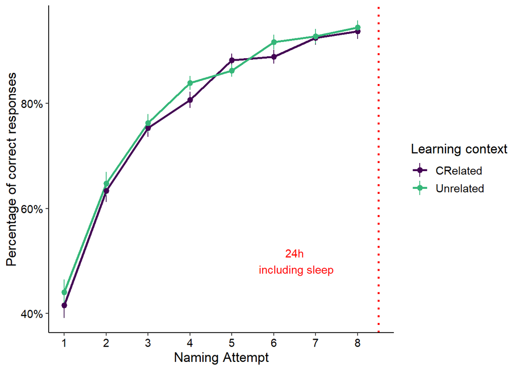

```r
(plot_acc <- ggplot(Acc3, aes(as.numeric(NamingAttempt), Acc, color = factor(LC))) +
  geom_line(size = 1) +
  geom_pointrange(aes(ymin = Acc - se, ymax = Acc + se), size = .4) +
  labs(x = "Naming Attempt",
       y = "Percentage of correct responses") +
  scale_y_continuous(labels = percent_format(accuracy = 2)) +
  scale_x_continuous(breaks = c(1:8)) +
  geom_vline(aes(xintercept = 8.5), color = "red", linetype = "dotted", size = 1) +
  annotate("text", x = 6.5, y = 0.5, label = "24h\n including sleep", color = "red") +
  theme_classic() +
  theme(axis.title.x = element_text(size = rel(1.2), colour = "black"),
        axis.title.y = element_text(size = rel(1.2), colour = "black"),
        panel.background = element_rect(colour = "white"),
        axis.text = element_text(size = rel(1), colour = "black"),
        legend.text = element_text(size = rel(1), colour = "black"),
        legend.title = element_text(size = rel(1.2), colour = "black"),
        axis.line = element_line(colour = "black")) +
  scale_color_manual(name = "Learning context",
                     labels = c("CRelated", "Unrelated"),
                     values = c("#440154FF", "#35B779FF")))
```

# Fit the model

Start with the maximal model:

```r
m1 <- glmer(Accuracy ~ cond +
             (1 + cond|Subj) +
             (1 + cond|NovelName),
           data = data2, family = binomial(link = "logit"))

# Check random structure of the model:
options(scipen = 999)
summary(rePCA(m1))
```

```
## $Subj
## Importance of components:
##                          [,1]    [,2]
## Standard deviation     1.0548 0.33682
## Proportion of Variance 0.9075 0.09254
## Cumulative Proportion  0.9075 1.00000
##
## $NovelName
## Importance of components:
##                          [,1]   [,2]
## Standard deviation     0.6104 0.2581
## Proportion of Variance 0.8483 0.1517
## Cumulative Proportion  0.8483 1.0000
```

```r
VarCorr(m1)
```

```
##  Groups    Name        Std.Dev. Corr
##  Subj      (Intercept) 1.05349
##            cond        0.34082  0.145
##  NovelName (Intercept) 0.60884
##            cond        0.26182  0.152
```

```r
# Did the model converge? Singularity issues?
print(summary(m1), corr = F)
```

```
## Generalized linear mixed model fit by maximum likelihood (Laplace
##   Approximation) [glmerMod]
##  Family: binomial  ( logit )
## Formula: Accuracy ~ cond + (1 + cond | Subj) + (1 + cond | NovelName)
##    Data: data2
##
##      AIC      BIC   logLik deviance df.resid
##  10263.4  10322.2  -5123.7  10247.4    11512
##
## Scaled residuals:
##     Min      1Q  Median      3Q     Max
## -9.4515  0.1426  0.3194  0.5125  2.1715
##
## Random effects:
##  Groups    Name        Variance Std.Dev. Corr
##  Subj      (Intercept) 1.10985  1.0535
##            cond        0.11616  0.3408   0.14
##  NovelName (Intercept) 0.37069  0.6088
##            cond        0.06855  0.2618   0.15
## Number of obs: 11520, groups:  Subj, 60; NovelName, 60
##
## Fixed effects:
##             Estimate Std. Error z value            Pr(>|z|)
## (Intercept)  1.70113    0.16038  10.607 <0.0000000000000002 ***
## cond         0.07985    0.06407   1.246               0.213
## ---
## Signif. codes:  0 '***' 0.001 '**' 0.01 '*' 0.05 '.' 0.1 ' ' 1
```

Model with no condition:

```r
m2 <- glmer(Accuracy ~ 1 +
             (1 + cond|Subj) +
             (1 + cond|NovelName),
           data = data2, family = binomial(link = "logit"))

# Did the model converge? Singularity issues?
print(summary(m2), corr = F)
```

```
## Generalized linear mixed model fit by maximum likelihood (Laplace
##   Approximation) [glmerMod]
##  Family: binomial  ( logit )
## Formula: Accuracy ~ 1 + (1 + cond | Subj) + (1 + cond | NovelName)
##    Data: data2
##
##      AIC      BIC   logLik deviance df.resid
##  10262.9  10314.4  -5124.5  10248.9    11513
##
## Scaled residuals:
##     Min      1Q  Median      3Q     Max
## -9.1677  0.1443  0.3188  0.5139  2.1717
##
## Random effects:
##  Groups    Name        Variance Std.Dev. Corr
##  Subj      (Intercept) 1.10712  1.0522
##            cond        0.11829  0.3439   0.10
##  NovelName (Intercept) 0.36953  0.6079
##            cond        0.06932  0.2633   0.13
## Number of obs: 11520, groups:  Subj, 60; NovelName, 60
##
## Fixed effects:
##             Estimate Std. Error z value            Pr(>|z|)
## (Intercept)   1.6820     0.1613   10.43 <0.0000000000000002 ***
## ---
## Signif. codes:  0 '***' 0.001 '**' 0.01 '*' 0.05 '.' 0.1 ' ' 1
```

```r
# Check random structure of the model:
summary(rePCA(m2))
```

```
## $Subj
## Importance of components:
##                          [,1]    [,2]
## Standard deviation     1.0528 0.34194
## Proportion of Variance 0.9046 0.09542
## Cumulative Proportion  0.9046 1.00000
##
## $NovelName
## Importance of components:
##                          [,1]   [,2]
## Standard deviation     0.6090 0.2607
## Proportion of Variance 0.8451 0.1549
## Cumulative Proportion  0.8451 1.0000
```

```r
VarCorr(m2)
```

```
##  Groups    Name        Std.Dev. Corr
##  Subj      (Intercept) 1.05220
##            cond        0.34393  0.102
##  NovelName (Intercept) 0.60789
##            cond        0.26329  0.126
```

Model comparison:

```r
anova(m1, m2)
```

```
## Data: data2
## Models:
## m2: Accuracy ~ 1 + (1 + cond | Subj) + (1 + cond | NovelName)
## m1: Accuracy ~ cond + (1 + cond | Subj) + (1 + cond | NovelName)
##    npar   AIC   BIC  logLik deviance Chisq Df Pr(>Chisq)
## m2    7 10263 10314 -5124.5    10249
## m1    8 10263 10322 -5123.7    10247 1.529  1     0.2163
```

**Confidence intervals**

```r
ConfidInt <- confint(m1, parm = c("(Intercept)", "cond"), method = "boot")
round(ConfidInt, 3)
```

```
##              2.5 % 97.5 %
## (Intercept)  1.404  2.055
## cond        -0.047  0.199
```

**Table of effects**

Fixed-effect coefficients and confidence intervals on the log-odds scale:

```r
tab_model(m1, terms = "cond", pred.labels = "Learning context", transform = NULL, show.stat = TRUE, show.se = TRUE, string.se = "SE", show.ci = FALSE, show.re.var = FALSE, show.ngroups = FALSE, show.icc = FALSE, emph.p = FALSE, dv.labels = "Response accuracy")
```

|  | Response accuracy |  |  |  |
| --- | --- | --- | --- | --- |
| Predictors | Log-Odds | SE | Statistic | p |
| Learning context | 0.08 | 0.06 | 1.25 | 0.213 |
| Observations | 11520 |  |  |  |
| Marginal R<sup>2</sup> / Conditional R<sup>2</sup> | 0.001 / 0.337 |  |  |  |

Exponentiate to get odds ratios:

```r
tab_model(m1, terms = "cond", pred.labels = "Learning context", show.stat = TRUE, show.se = TRUE, string.se = "SE", show.ci = FALSE, show.re.var = FALSE, show.icc = FALSE, show.ngroups = FALSE, emph.p = FALSE, dv.labels = "Response accuracy")
```

|  | Response accuracy |  |  |  |
| --- | --- | --- | --- | --- |
| Predictors | Odds Ratios | SE | Statistic | p |
| Learning context | 1.08 | 0.06 | 1.25 | 0.213 |
| Observations | 11520 |  |  |  |
| Marginal R<sup>2</sup> / Conditional R<sup>2</sup> | 0.001 / 0.337 |  |  |  |

Reminder: Put simply, the odds ratio (OR) measures whether an outcome is associated with some manipulation or not. In other words, the OR is the odds that an outcome will occur given a particular manipulation, compared to the odds of the outcome occurring in the absence of that manipulation. Odds of 1 corresponds to the probability of 0.50.

Probability, odds ratios and log-odds are all the same thing, just expressed in different ways.

Probability is the probability an event happens. Odds (of success) is defined as probability of success/probability of failure.nLog odds is the logarithm of the odds.

**Plot of effects**

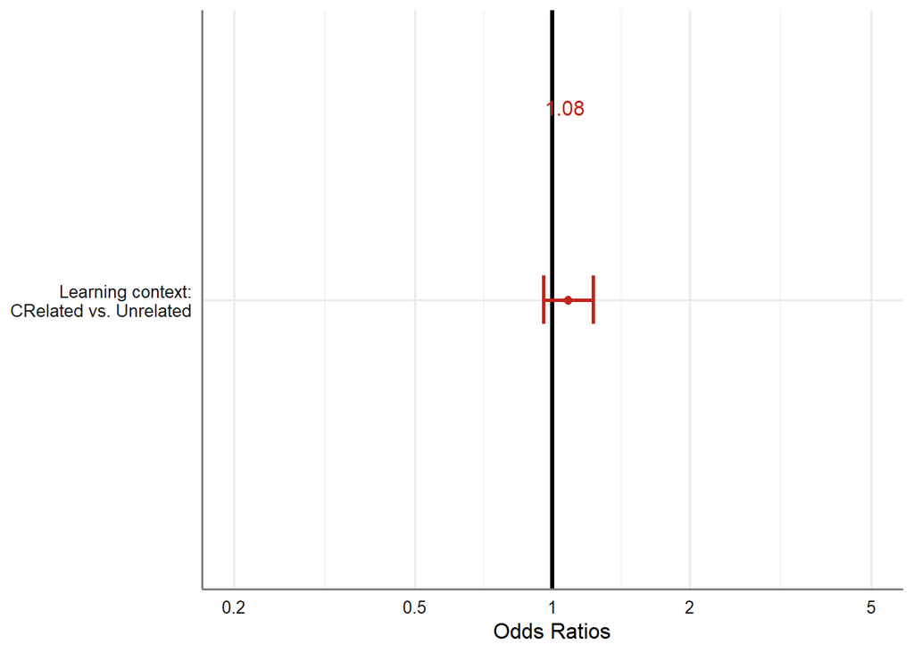

```r
labels <- c("Learning context: CRelated vs. Unrelated")

keep.terms <- names(fixef(m1)[-1])

plot_model(m1, title = "", terms = keep.terms, axis.labels = rev(labels),
           type = "est", sort.est = NULL, colors = "bw",
           show.values = TRUE, show.p = TRUE, value.offset = 0.4,
           value.size = 4, dot.size = 2, line.size = 1,
           vline.color = "black",
           width = 0.1) + theme_sjplot2() +
           scale_color_sjplot(palette = "circus")
```